# Praca domowa 1

Jakub Wiśniewski

3/8/2020

# 1 Eksploracja Danych

## 1.1 Dane

Dane pochodzą z OpemML100, jest to zbiór https://www.openml.org/d/29 . Jest ciekawy do eksploracji, ponieważ ma zmienne kategoryczne i ciągłe, o różnych rozkładach, oraz kilka missing values.

## 1.2 Typy, struktura danych

Dane mają konkretną strukturę

```r
str(df)
```

```
## 'data.frame':    690 obs. of  16 variables:
##  $ A1   : chr  "b" "a" "a" "b" ...
##  $ A2   : chr  "30.83" "58.67" "24.50" "27.83" ...
##  $ A3   : num  0 4.46 0.5 1.54 5.62 ...
##  $ A4   : chr  "u" "u" "u" "u" ...
##  $ A5   : chr  "g" "g" "g" "g" ...
##  $ A6   : chr  "w" "q" "q" "w" ...
##  $ A7   : chr  "v" "h" "h" "v" ...
##  $ A8   : num  1.25 3.04 1.5 3.75 1.71 ...
##  $ A9   : chr  "t" "t" "t" "t" ...
##  $ A10  : chr  "t" "t" "f" "t" ...
##  $ A11  : int  1 6 0 5 0 0 0 0 0 0 ...
##  $ A12  : chr  "f" "f" "f" "t" ...
##  $ A13  : chr  "g" "g" "g" "g" ...
##  $ A14  : chr  "00202" "00043" "00280" "00100" ...
##  $ A15  : int  0 560 824 3 0 0 31285 1349 314 1442 ...
##  $ class: chr  "+" "+" "+" "+" ...
```

Trzeba uważać na “zamaskowane” missing values

```r
unique(df$A4)
```

```
## [1] "u" "y" "?" "l"
```

Tak wygląda nasza ramka danych.

```r
DT::datatable(df)
```

|  | A1 | A2 | A3 | A4 | A5 | A6 | A7 | A8 | A9 | A10 | A11 | A12 | A13 | A14 | A15 | class |
| --- | --- | --- | --- | --- | --- | --- | --- | --- | --- | --- | --- | --- | --- | --- | --- | --- |
| 1 | b | 30.83 | 0 | u | g | w | v | 1.25 | t | t | 1 | f | g | 00202 | 0 | + |
| 2 | a | 58.67 | 4.46 | u | g | q | h | 3.04 | t | t | 6 | f | g | 00043 | 560 | + |
| 3 | a | 24.50 | 0.5 | u | g | q | h | 1.5 | t | f | 0 | f | g | 00280 | 824 | + |
| 4 | b | 27.83 | 1.54 | u | g | w | v | 3.75 | t | t | 5 | t | g | 00100 | 3 | + |
| 5 | b | 20.17 | 5.625 | u | g | w | v | 1.71 | t | f | 0 | f | s | 00120 | 0 | + |
| 6 | b | 32.08 | 4 | u | g | m | v | 2.5 | t | f | 0 | t | g | 00360 | 0 | + |
| 7 | b | 33.17 | 1.04 | u | g | r | h | 6.5 | t | f | 0 | t | g | 00164 | 31285 | + |
| 8 | a | 22.92 | 11.585 | u | g | cc | v | 0.04 | t | f | 0 | f | g | 00080 | 1349 | + |
| 9 | b | 54.42 | 0.5 | y | p | k | h | 3.96 | t | f | 0 | f | g | 00180 | 314 | + |
| 10 | b | 42.50 | 4.915 | y | p | w | v | 3.165 | t | f | 0 | t | g | 00052 | 1442 | + |

[output cut: 680 more lines]

Zmieńmy ? na NA, oraz nadajmy factory komlumnom bez wartości numerycznych.

```r
for (col in colnames(df)){
  df[df[col] == "?",col] <- NA
}


change_to_factor <- function(df){
for (i in seq_along(colnames(df))){
    if (!is.numeric(df[,i])){
      df[,i] <- as.factor(df[,i])
      }
}
  return(df)
}
df <- change_to_factor(df)


df$A2 <- as.numeric(df$A2)
df$A14 <- as.numeric(df$A2)

str(df)
```

```
## 'data.frame':    690 obs. of  16 variables:
##  $ A1   : Factor w/ 2 levels "a","b": 2 1 1 2 2 2 2 1 2 2 ...
##  $ A2   : num  157 329 90 126 44 169 180 75 311 256 ...
##  $ A3   : num  0 4.46 0.5 1.54 5.62 ...
##  $ A4   : Factor w/ 3 levels "l","u","y": 2 2 2 2 2 2 2 2 3 3 ...
##  $ A5   : Factor w/ 3 levels "g","gg","p": 1 1 1 1 1 1 1 1 3 3 ...
##  $ A6   : Factor w/ 14 levels "aa","c","cc",..: 13 11 11 13 13 10 12 3 9 13 ...
##  $ A7   : Factor w/ 9 levels "bb","dd","ff",..: 8 4 4 8 8 8 4 8 4 8 ...
##  $ A8   : num  1.25 3.04 1.5 3.75 1.71 ...
##  $ A9   : Factor w/ 2 levels "f","t": 2 2 2 2 2 2 2 2 2 2 ...
##  $ A10  : Factor w/ 2 levels "f","t": 2 2 1 2 1 1 1 1 1 1 ...
##  $ A11  : int  1 6 0 5 0 0 0 0 0 0 ...
##  $ A12  : Factor w/ 2 levels "f","t": 1 1 1 2 1 2 2 1 1 2 ...
##  $ A13  : Factor w/ 3 levels "g","p","s": 1 1 1 1 3 1 1 1 1 1 ...
##  $ A14  : num  157 329 90 126 44 169 180 75 311 256 ...
##  $ A15  : int  0 560 824 3 0 0 31285 1349 314 1442 ...
##  $ class: Factor w/ 2 levels "-","+": 2 2 2 2 2 2 2 2 2 2 ...
```

Tak wyglądają typy danych w naszym zbiorze.

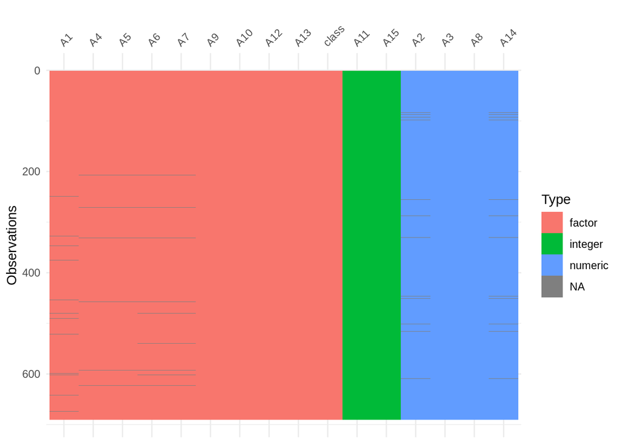

```r
vis_dat(df)
```

Jak widzimy, nie ma zbyt wielu missing values.

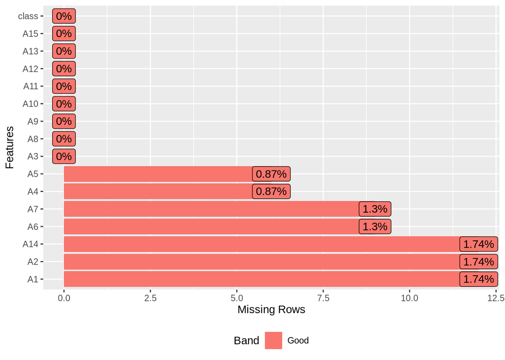

```r
DataExplorer::plot_missing(df)
```

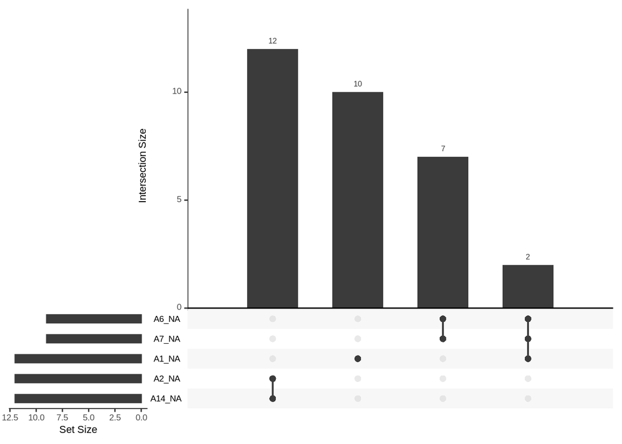

```r
gg_miss_upset(df)
```

## 1.3 Rozkłady kolumn

Kolumny, które mają rozkłady dyskretne, prezentują sie tak:

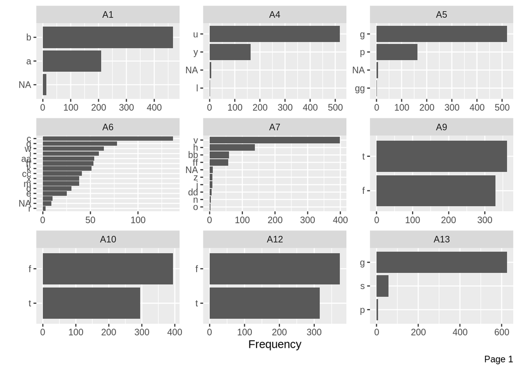

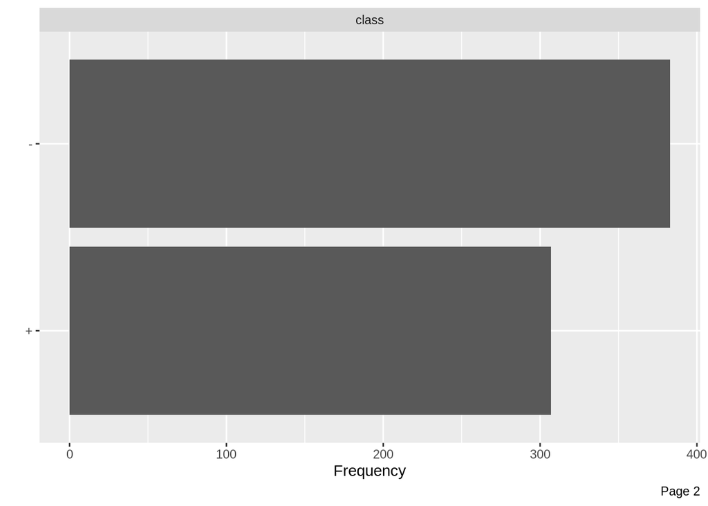

```r
DataExplorer::plot_bar(df)
```

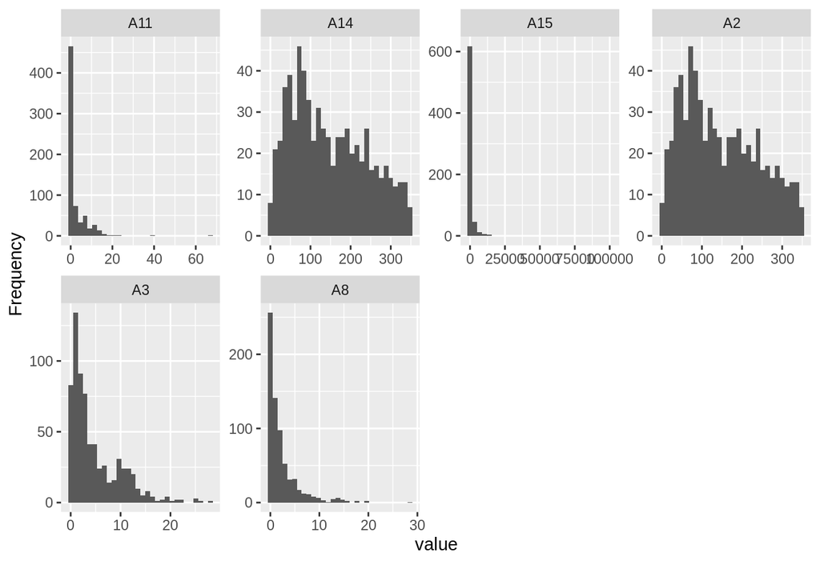

```r
DataExplorer::plot_histogram(df)
```

## 1.4 Zaawansowana Analiza

Sprawdźmy, jak bardzo różni się rozkład zmiennej A2 od rozkładu normalnego . Widzimy, że na “ogonach” odbiega on znacznie od rozkładu normalnego.

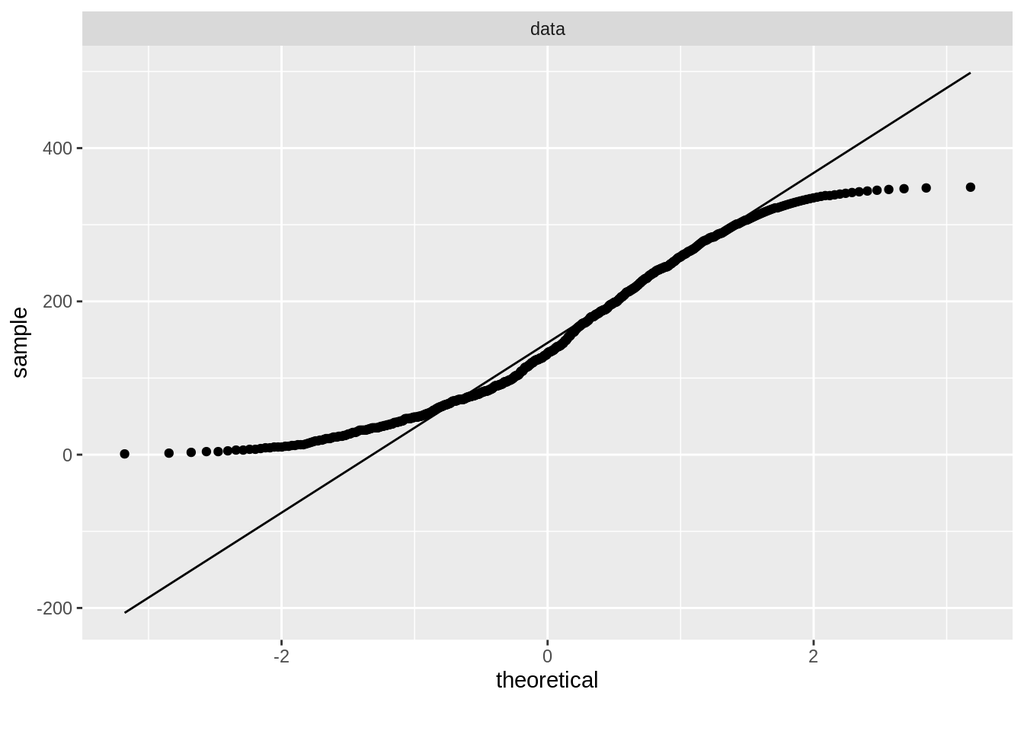

```r
DataExplorer::plot_qq(df$A2)
```

Niektóre dane są ze sobą skorelowane. Przykładowo zmienne ciągłe zdają się być ze sobą skorelowane na poziomie 0.3-0.5.

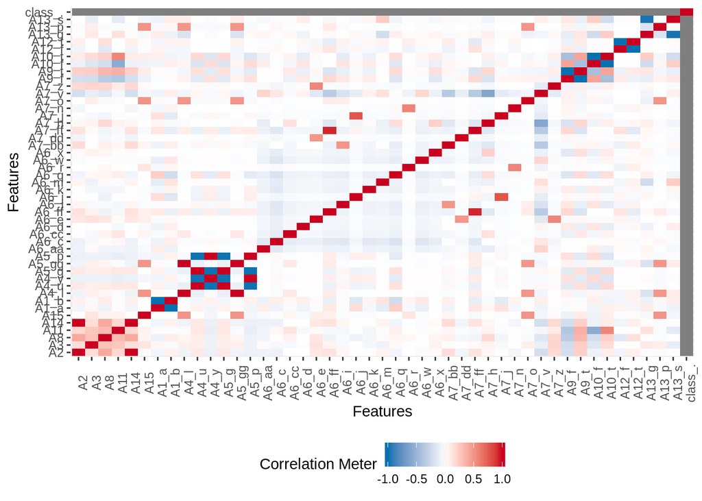

```r
DataExplorer::plot_correlation(na.omit(df))
```

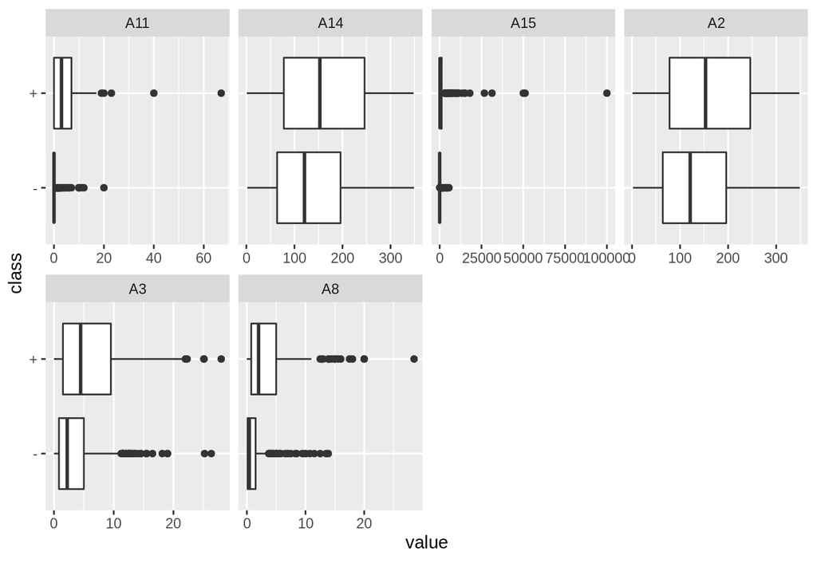

```r
DataExplorer::plot_boxplot(df, by = "class")
```

Niestety nie jesteśmy w stanie się dowiedzieć co oznaczają dane zmienne i tym samym nadać naszym eksploracjom sens. Spróbujmy jednak stworzyć kilka wykresów, które pozwolą troszkę lepiej zrozumieć co dzieje się w naszych danych.

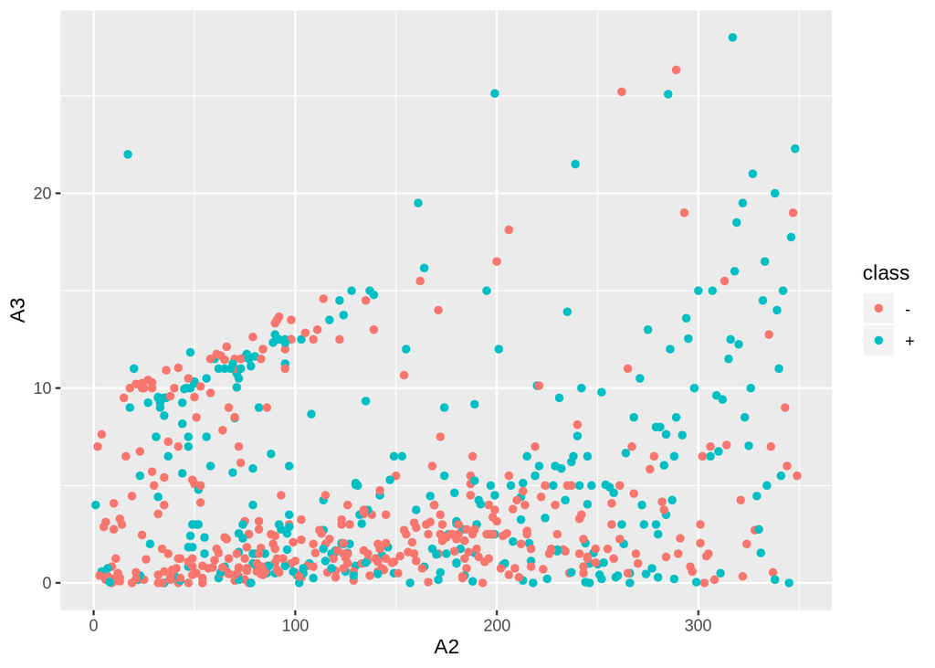

```r
ggplot(df, aes(A2, A3, color = class)) + geom_point()
```

Zwróćmy uwagę na poniższy wykres. Wiemy, że klasa `+` i klasa `-` to albo przyznanie albo nie przyznanie kredytu. Możemy dzięki temu postawić tezę, że A15 to ilość pieniędzy w banku. Miałoby to sens, gdyż outliery mają głównie kolor niebieski.

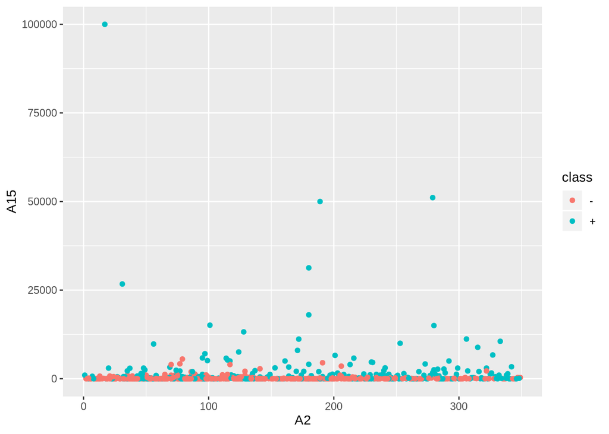

```r
ggplot(df, aes(A2, A15, color = class)) + geom_point()
```

Biorąc pod uwagę obserwacje zmiennej A15 większe niż 6 tysięcy, możemy potwierdzić nasze przypuszczenia, że wysokie wartości A15 skutkują przyznaniem kredytu.

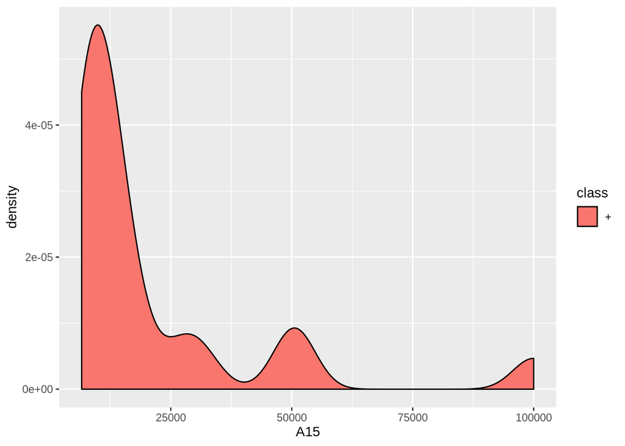

```r
ggplot(df[df$A15 > 6000,], aes(A15, fill = class)) + geom_density()
```

W przypadku zmiennej A8 obserwacje klasy `+` mają dłuższy i grubszy ogon, a więcej klasy `-` jest przy zerze.

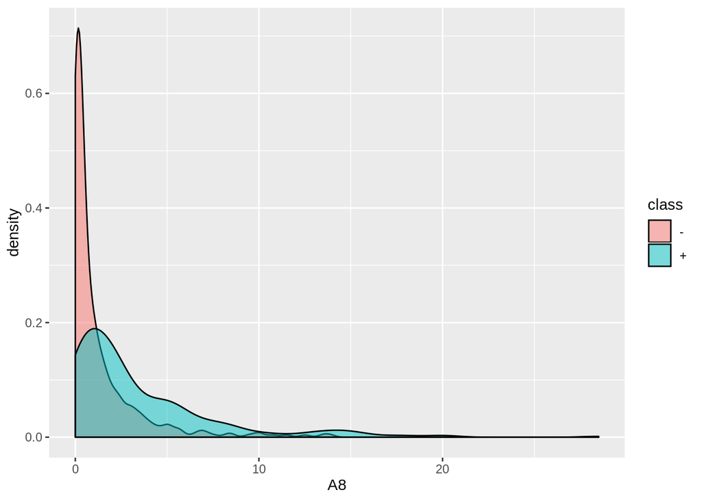

```r
ggplot(df, aes(A8, fill = class)) + geom_density(alpha = 0.5)
```

Podobnie jest w przypadku A11

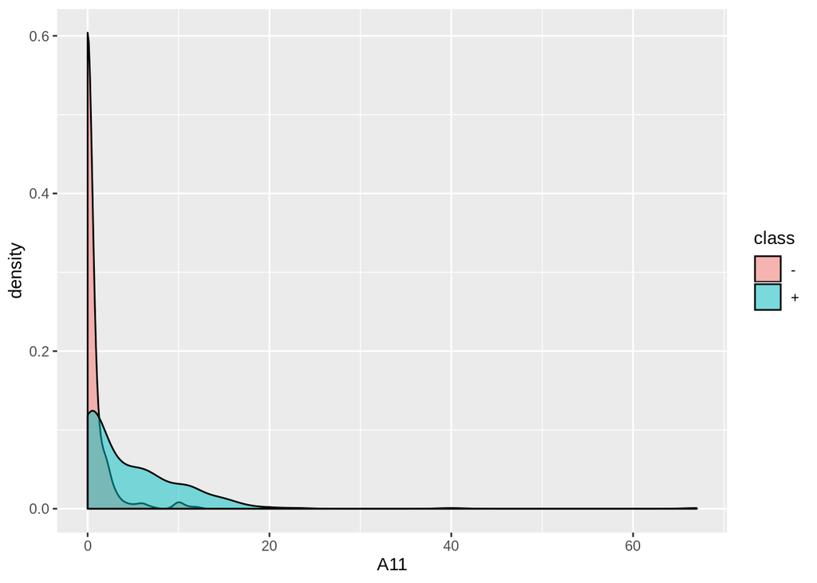

```r
ggplot(df, aes(A11, fill = class)) + geom_density(alpha = 0.5)
```

# 2 Uczenie maszynowe z wykorzystaniem różnych prostych technik obróbki brakujących danych

## 2.1 Przygotowanie danych, modeli

Algorytm machine learningowy, z którego będę korzystał to Random Forest (uwielbiam ten algorytm, gdyż robiłem go na projekt w Javie i totalnie się nie udało :( ).

```r
library(randomForest) # korzystamy z Lasu Losowego

n <- length(df$A1) # ilość obserwacji

# permutuję zbiór
idx_permutation <- sample(1:n, n)
df <- df[idx_permutation, ]

# podział 80-20
train <- df[1:round(0.8*n), ]
test <- df[(round(0.8*n)+1):n,]
```

Następnie prostymi technikami obrabiam dane

1. Omijanie brakujących danych

```r
train1 <- na.omit(train)
test1  <- na.omit(test)
```

2. Omijam kolumny z brakującymi danymi

```r
# tutaj w tych samych kolumnach są braki danych, więc możemy tak zrobić
train2 <- train[ , colSums(is.na(train)) == 0]
test2  <- test[ , colSums(is.na(test)) == 0]
```

3. Wartości ciągłe medianą, a dyskretne modą

```r
numeric_input_mean <- function(df){
  for (i in seq_along(colnames(df))){
    if (is.numeric(df[,i])){
      col_median <- median(df[,i], na.rm = TRUE)
      df[is.na(df[,i]),i] <- col_median
  }
}
  return(df)
}

categorical_input_mode <- function(df){
  for (i in seq_along(colnames(df))){
    if (is.factor(df[,i])){
      uniqv <- unique(df[,i])
      col_mode <- uniqv[which.max(tabulate(match(df[,i], uniqv)))]
      df[is.na(df[,i]),i] <- col_mode
  }
}
  return(df)
}

train3 <- numeric_input_mean(train)
test3 <- numeric_input_mean(test)

train3 <- categorical_input_mode(train3)
test3 <- categorical_input_mode(test3)
```

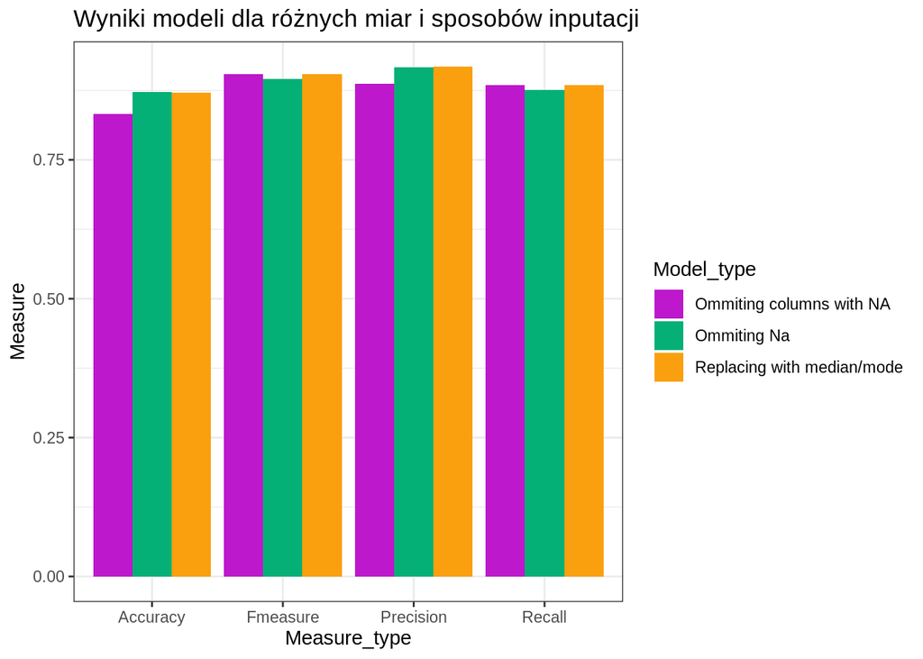

```r
library(caret) # for confussion matrix
acc <- c(0,0,0)
precision <- c(0,0,0)
recall <- c(0,0,0)
Fmeasure <- c(0,0,0)

for (i in 1:100){

model_rf_1 <- randomForest(class ~., data = train1, probability = TRUE)

model_rf_2 <- randomForest(class ~., data = train2, probability = TRUE)

model_rf_3 <- randomForest(class ~., data = train3, probability = TRUE)

pred1 <- predict(model_rf_1, newdata = test1)
pred2 <- predict(model_rf_2, newdata = test2)
pred3 <- predict(model_rf_3, newdata = test3)

# accuracy
acc[1] <- acc[1] + sum(test1$class == pred1)/length(pred1)
acc[2] <- acc[2] +  sum(test2$class == pred2)/length(pred2)
acc[3] <- acc[3] + sum(test3$class == pred3)/length(pred3)


# confusion matrix

# Precision TP / (TP + FP)
precision[1] <- precision[1] +precision(data = pred1 , reference = test1$class)
precision[2] <- precision[2] + precision(data = pred2 , reference = test2$class)
precision[3] <- precision[3] + precision(data = pred3 , reference = test3$class)

# Recall TP/(TP+FN)
recall[1] <- recall[1] +  recall(data = pred1 , reference = test1$class)
recall[2] <- recall[1] +  recall(data = pred2 , reference = test2$class)
recall[3] <- recall[1] +  recall(data = pred3 , reference = test3$class)

# 2* (precision*recall)/(precision + recall)
Fmeasure[1] <- Fmeasure[1] +   F_meas(data = pred1 , reference = test1$class)
Fmeasure[2] <- Fmeasure[1] +   F_meas(data = pred2 , reference = test2$class)
Fmeasure[3] <- Fmeasure[1] +   F_meas(data = pred3 , reference = test3$class)


}

 res <- data.frame(Measure =  c(acc/100, precision/100,recall/100,Fmeasure/100),
                  Measure_type = c(rep("Accuracy",3), rep("Precision",3), rep("Recall",3), rep("Fmeasure",3)),
                   Model_type = rep(c("Ommiting Na", "Ommiting columns with NA", "Replacing with median/mode"),4))

ggplot(res, aes(Measure_type,Measure, fill=Model_type)) + geom_bar(position = "dodge", stat = "identity") +
  scale_fill_manual(values = c("#bd18cc","#04b076","#faa00f")) + theme_bw() + ggtitle("Wyniki modeli dla różnych miar i sposobów inputacji")
```

```r
res
```

| Measure | Measure_type | Model_type |
| --- | --- | --- |
| 0.8718182 | Accuracy | Ommiting Na |
| 0.8325362 | Accuracy | Ommiting columns with NA |
| 0.8705797 | Accuracy | Replacing with median/mode |
| 0.9162685 | Precision | Ommiting Na |
| 0.8871117 | Precision | Ommiting columns with NA |
| 0.9174319 | Precision | Replacing with median/mode |
| 0.8762651 | Recall | Ommiting Na |
| 0.8847708 | Recall | Ommiting columns with NA |
| 0.8850007 | Recall | Replacing with median/mode |
| 0.8958005 | Fmeasure | Ommiting Na |

[output cut: 2 more lines]